# Dac summary 01/19/2021

Erica Baller

4/15/2021

## Dac summary

Welcome to the MS project! This is a really exciting project dedicated to understanding psychopathology, particular depression in patients with MS. It is unqiue in a variety of ways, primarily that it uses clinical images that are research grade.

The team so far is big. PIs- Ted Satterthwaite and Taki Shinohara Senior Scientists - Azeez Adebimpe and Matt Cieslak Research Specialist- Timothy Robert-Fitzgerald Graduate students - Melissa Martin Data Analysist - Sidney Covitz Collaborators - Aaron Alexander-Bloch and Jenna Young DAC Pull done by - Victoria Rautman(2020/2021) and Sunil Thomas (2018)

Date of FINAL Pull: 1/19/2021 Spreadsheet: /Users/eballer/BBL/msdepression/data/dac/investigatingdepressioninmspatients.csv Summary of request to Victoria @ DAC: — 9/2/2020

DAC Request Non-funded IRB Approved Research (enter IRB number): 843669 Criteria Display? Description / Exclusions / Limitations / Filters MRN Y Unique identifier requested, but can be masked MRN Visit ID Y  
Patient Class(es) Please select only which class(es) you will need. x Inpatient X Outpatient x Emergency Age or DOB ranges Y  
Gender Y  
Race Y  
Department(s) Provide department numbers not just names. N  
Provider(s) Provide ID’s not just names. N  
Date(s) Include in the specific range and date types (eg, admit, order, result) 1/1/2010- 12/31/20 All scans based on date of first treatment with glatiramer acetate Procedure Please include the specific procedure codes. (ICD9/ICD10 is preferred for inpatient) Y 88.91 (Magnetic Resonance Imaging of Brain)

Diagnosis Please include the specific ICD-9/ICD-10 codes including all decimal points. Do not simply include ranges or wildcards. Y Multiple sclerosis (ICD-9: 340; ICD-10: G35), Depressive disorders (ICD-9: 296.99, 296.21, 296.22, 296.23, 296.24, 296.25, 296.26, 296.20, 296.31, 296.32, 296.33, 296.34, 296.35, 296.26, 296.30, 300.4, 293.83, 311, ICD-10: F32.0, F32.1, F32.2, F32.3, F32.4, F32.5, F32.6, F33.0, F33.1, F33.2, F33.41, F33.42, F33.9, F34.1, F06.31, F06.32, F06.34, F32.8, F32.9, major depressive disorder, persistent depressive disorder, depressive disorder due to another medical condition, other specified depressive disorder, unspecified depressive disorder) Orders N  
Medication Please list as it is ordered within the UPHS EMR’s – medication id’s preferred Y Glatiramer Acetate (Copaxone) Lab Result Please list the lab as it is ordered within the UPHS EMR’s. Y  
Other Y EDSS scores (if present) Other Y All medications patients are receiving Other Y All PACS accession numbers available Other Y PHQ-2 and PHQ-9 if present — 9/16/2020: Per her note to me: We also specified that we wanted to pull images with ORIG_CPT values of 70551, 70552, 70553, MHDI, IMGMR0128, and we wanted scans with department ID 361, 547, 6004, or 6013. And I may have mentioned this before but the ICD9 and ICD10 codes for MS patients are 340 and G35, respectively

*For us, we are additionally interested in ALL ICD9/10 codes, ALL medications they are on at the time of scan, specific labs (as indicated), EDSS , PHQ-9 and 2 scores. The particular reason for this is that we are going to be looking at the relationship of brain imaging to depression in the MS group.

Mock columns: DE_PAT_ID PAT_ID EMPI HUP_MRN PAT_NM_WMRN SEX RACE ETHNIC_GROUP ORDER_ID ORDERING_DTTM BEGIN_EXAM_DTTM END_EXAM_DTTM TECH_USER_ID TECHNOLOGIST ACCESSION_NUM PROC_ID PROC_NAME PROC_CODE ORIG_CPT PERFORMING_CSN_ID COVERAGE_ID FIN_CLASS_NAME VISIT_EPM_ID PERFORMING_DEP_ID DEPARTMENT_NAME MODALITY ASSOCIATED_ICD9 ASSOCIATED_ICD10 PAT_AGE_AT_EXAM MRI_ENC_AGE CURRENT_AGE All ICD-9 or 10 codes All medication codes wbc rbc hemoglobin csf studies… phq-9 score (and date) phq-2 score (and date) b12 folate TSH RPR Vit D

Radiology sent images to Taki and group 4/2021

This script goes through data that has been returned from the DAC on 1/19 and summarizes it

```r
#preprocessing - because these are sent


#load our df

#from Jan 2021 pull
data <- read.csv("/Users/eballer/BBL/msdepression/data/dac/investigatingdepressioninmspatients.csv", header = TRUE, stringsAsFactors = FALSE, na.strings = c("NULL"), sep =",")

ms_providers <- c("MARKOWITZ, CLYDE E.", "JACOBS, DINA A.", "WILLIAMSON, ERIC MICHAEL-LEE", "BERGER, JOSEPH ROBERT", "BERGER DO, JOSEPH", "PRUITT, AMY A.", "KOLSON, DENNIS L.", "CHAHIN, SALIM", "NARULA, SONA", "BAR-OR, AMIT")


#keep people with MS providers
data_empi_acc_f_phq <- data[which(data$Provider %in% ms_providers),] #n = 17067

#keep people with ICD10 code G35 (this is the same # as people with IC9 - 340)
data_empi_acc_f_phq <- data_empi_acc_f_phq[grep("G35", data_empi_acc_f_phq$ICD10),] #n = 16830
table(data_empi_acc_f_phq$Provider)
```

```
##
##                 BAR-OR, AMIT            BERGER DO, JOSEPH
##                           93                            1
##        BERGER, JOSEPH ROBERT                CHAHIN, SALIM
##                         1818                          260
##              JACOBS, DINA A.            KOLSON, DENNIS L.
##                         4765                          643
##          MARKOWITZ, CLYDE E.                 NARULA, SONA
##                         6245                          274
##               PRUITT, AMY A. WILLIAMSON, ERIC MICHAEL-LEE
##                         1372                         1359
```

```r
##########################
### some preprocessing ###
##########################

#make accession # and lab findings into integer type, contained in row 28:42, Margin=2 to work on columns
data_empi_acc_f_phq$ACCESSION_NUM <- as.integer(data_empi_acc_f_phq$ACCESSION_NUM)
data_empi_acc_f_phq[27:29] <- apply(X = data_empi_acc_f_phq[27:29], FUN = as.integer, MARGIN = 2)
data_empi_acc_f_phq[31:45] <- apply(X = data_empi_acc_f_phq[31:45], FUN = as.integer, MARGIN = 2)
```

```r
data_empi_acc_f_phq$sex_binarized <- ifelse(data_empi_acc_f_phq$SEX == "MALE", 1, 2)
data_empi_acc_f_phq$race_binarized <- ifelse(data_empi_acc_f_phq$RACE == "WHITE", 1, 2)

########################################
#### Start counting / making subsets ###
########################################

# number of unique scanners and scans
print(paste0("Number of unique procedure names (ie. MRI Head w/out contrast; MRI Source Images): ",  length(unique(data_empi_acc_f_phq$PROC_CODE)))) #n = 10
```

```
## [1] "Number of unique procedure names (ie. MRI Head w/out contrast; MRI Source Images): 10"
```

```r
print(paste0("Number of unique department names (ie. RAD HUP PCAM Ground): ",  length(unique(data_empi_acc_f_phq$DEPARTMENT_NAME)))) #n = 3
```

```
## [1] "Number of unique department names (ie. RAD HUP PCAM Ground): 3"
```

```r
print(paste0("Number of unique modalities (ie. HUP PCAM GR MR4 3T; MR6 3T): ",  length(unique(data_empi_acc_f_phq$MODALITY)))) #n = 11
```

```
## [1] "Number of unique modalities (ie. HUP PCAM GR MR4 3T; MR6 3T): 11"
```

```r
print(paste0("Number of unique accession #s n= ", length(unique(data_empi_acc_f_phq$ACCESSION_NUM)))) # n = 16830
```

```
## [1] "Number of unique accession #s n= 16830"
```

```r
print(paste0("Number of unique EMPIS n = ", length(unique(data_empi_acc_f_phq$EMPI)))) #n = 3737
```

```
## [1] "Number of unique EMPIS n = 3737"
```

```r
#### PHQ-2 and PHQ-9 summaries

#looking at just people with phq-2 and 9
phq2_subset <- data_empi_acc_f_phq[which(!is.na(data_empi_acc_f_phq$PHQ.2)),] #n=4606

phq9_subset <- data_empi_acc_f_phq[which(!is.na(data_empi_acc_f_phq$PHQ.9)),] #n= 261

#phq-2;
print(paste0("N PHQ-2 = ", sum(!is.na(data_empi_acc_f_phq$PHQ.2)), "; n = ", length(which(phq2_subset$PHQ.2 >= 3)), " meeting criteria for depression (PHQ2) >= 3")) #n = 4606
```

```
## [1] "N PHQ-2 = 4606; n = 130 meeting criteria for depression (PHQ2) >= 3"
```

```r
#phq-9
print(paste0("N PHQ-9 = ", sum(!is.na(data_empi_acc_f_phq$PHQ.9)), "; noDep/mild/mod/mod-severe/severe = ",
             length(which(phq9_subset$PHQ.9 < 5)), "/",
             length(which(phq9_subset$PHQ.9 >= 5 & phq9_subset$PHQ.9 < 10)), "/",
             length(which(phq9_subset$PHQ.9 >= 10 & phq9_subset$PHQ.9 < 15)), "/",
             length(which(phq9_subset$PHQ.9 >= 15 & phq9_subset$PHQ.9 < 20)), "/",
             length(which(phq9_subset$PHQ.9 >= 20)))) #n = 261
```

```
## [1] "N PHQ-9 = 261; noDep/mild/mod/mod-severe/severe = 77/73/65/21/25"
```

```r
#both phq2 and 9

num_both_phq2_and_9 <- length(which(!is.na(data_empi_acc_f_phq$PHQ.2) & !is.na(data_empi_acc_f_phq$PHQ.9)))
print(paste0("num people with both phq2 and 9 = ", num_both_phq2_and_9)) #n = 0
```

```
## [1] "num people with both phq2 and 9 = 0"
```

```r
#Number of unique EMPIs in phq2/phq9 subsets
unique_phq2_empis <- length(unique(phq2_subset$EMPI)) #n=966
print(paste0("N with phq2 (Unique EMPI) n = ", unique_phq2_empis, " out of ", dim(phq2_subset)[1], "; n - ", length(unique(phq2_subset$EMPI[phq2_subset$PHQ.2 >= 3])), " meeting criteria for depression (PHQ2) >= 3")) #n = 4606
```

```
## [1] "N with phq2 (Unique EMPI) n = 899 out of 4606; n - 32 meeting criteria for depression (PHQ2) >= 3"
```

```r
unique_phq9_empis <- length(unique(phq9_subset$EMPI)) #n=76
print(paste0("N with phq9 (Unique EMPI) n = ", unique_phq9_empis, " out of ", dim(phq9_subset)[1], "; noDep/mild/mod/mod-severe/severe = ",
             length(unique(phq9_subset$EMPI[phq9_subset$PHQ.9 < 5])), "/",
             length(unique(phq9_subset$EMPI[(phq9_subset$PHQ.9 >= 5 & phq9_subset$PHQ.9 < 10)])), "/",
             length(unique(phq9_subset$EMPI[(phq9_subset$PHQ.9 >= 10 & phq9_subset$PHQ.9 < 15)])), "/",
             length(unique(phq9_subset$EMPI[(phq9_subset$PHQ.9 >= 15 & phq9_subset$PHQ.9 < 20)])), "/",
             length(unique(phq9_subset$EMPI[phq9_subset$PHQ.9 >= 20]))))
```

```
## [1] "N with phq9 (Unique EMPI) n = 68 out of 261; noDep/mild/mod/mod-severe/severe = 18/16/18/8/8"
```

```r
#### ICD 9/10 for Depression
dep_df <- data_empi_acc_f_phq[grep("F3", data_empi_acc_f_phq$ICD10),] #n = 2123
num_depression <- dim(dep_df)[1]
unique_empi <- which(unique(data_empi_acc_f_phq$EMPI) %in% data_empi_acc_f_phq$EMPI) #index of the locations of unique empis; n = 3885
num_unique_EMPI_and_dep <- length(unique(dep_df$EMPI)) #n = 493

print(paste0("N with ICD 9/10 codes for depression = ", num_depression))
```

```
## [1] "N with ICD 9/10 codes for depression = 2123"
```

```r
print(paste0("N with ICD 9/10 codes for depression and unique EMPI = ", num_unique_EMPI_and_dep, " out of ", dim(data_empi_acc_f_phq)[1]))
```

```
## [1] "N with ICD 9/10 codes for depression and unique EMPI = 493 out of 16830"
```

```r
##### PHQ2 or 9 + ICD 9/10 Depression
num_phq2_and_dep <- length(which(!is.na(dep_df$PHQ.2))) #n = 960
print(paste0("N with ICD 9/10 codes for depression and phq2 (ALL SCANS) = ", num_phq2_and_dep, " out of ", dim(dep_df)[1]))
```

```
## [1] "N with ICD 9/10 codes for depression and phq2 (ALL SCANS) = 960 out of 2123"
```

```r
num_phq9_and_dep <- length(which(!is.na(dep_df$PHQ.9))) #n=140
print(paste0("N with ICD 9/10 codes for depression and phq9 (ALL SCANS) = ", num_phq9_and_dep, " out of ", dim(dep_df)[1]))
```

```
## [1] "N with ICD 9/10 codes for depression and phq9 (ALL SCANS) = 140 out of 2123"
```

```r
#phq-2;
print(paste0("N dep + PHQ-2 = ", sum(!is.na(dep_df$PHQ.2)), "; n = ", length(which(dep_df$PHQ.2 >= 3)), " meeting criteria for depression (PHQ2) >= 3")) #n = 4606
```

```
## [1] "N dep + PHQ-2 = 960; n = 83 meeting criteria for depression (PHQ2) >= 3"
```

```r
#phq-9
print(paste0("N dep + PHQ-9 = ", sum(!is.na(dep_df$PHQ.9)), "; noDep/mild/mod/mod-severe/severe = ",
             length(which(dep_df$PHQ.9 < 5)), "/",
             length(which(dep_df$PHQ.9 >= 5 & dep_df$PHQ.9 < 10)), "/",
             length(which(dep_df$PHQ.9 >= 10 & dep_df$PHQ.9 < 15)), "/",
             length(which(dep_df$PHQ.9 >= 15 & dep_df$PHQ.9 < 20)), "/",
             length(which(dep_df$PHQ.9 >= 20)))) #n = 261
```

```
## [1] "N dep + PHQ-9 = 140; noDep/mild/mod/mod-severe/severe = 22/39/44/20/15"
```

```r
#### # unique people with dep dx and phq2/9 -> working on this
dep_dx_phq2_unique <- length(unique(dep_df$EMPI[!is.na(dep_df$PHQ.2)])) #n = 201
print(paste0("N with ICD 9/10 codes for depression and phq2 (unique) = ", dep_dx_phq2_unique, " out of ", dim(dep_df)[1]))
```

```
## [1] "N with ICD 9/10 codes for depression and phq2 (unique) = 201 out of 2123"
```

```r
dep_dx_phq9_unique <- length(unique(dep_df$EMPI[!is.na(dep_df$PHQ.9)])) #n = 43
print(paste0("N with ICD 9/10 codes for depression and phq9 (unique) = ", dep_dx_phq9_unique, " out of ", dim(dep_df)[1]))
```

```
## [1] "N with ICD 9/10 codes for depression and phq9 (unique) = 43 out of 2123"
```

```r
####


#### ICD 9/10 for Healthy Group
healthy_df <- data_empi_acc_f_phq[(-grep("F3", data_empi_acc_f_phq$ICD10)),] #n = 14707
num_healthy <- dim(healthy_df)[1]
unique_empi <- which(unique(healthy_df$EMPI) %in% healthy_df$EMPI) #index of the locations of unique empis; n = 3244
num_unique_EMPI_and_healthy <- length(unique(healthy_df$EMPI)) #n = 3244

print(paste0("N without Depression/ICD 9/10 codes for healthy = ", num_healthy))
```

```
## [1] "N without Depression/ICD 9/10 codes for healthy = 14707"
```

```r
print(paste0("N without Depression/ ICD 9/10 codes for healthy and unique EMPI = ", num_unique_EMPI_and_healthy, " out of ", dim(healthy_df)[1]))
```

```
## [1] "N without Depression/ ICD 9/10 codes for healthy and unique EMPI = 3244 out of 14707"
```

```r
##### PHQ2 or 9 + No Depression ICD9/10
num_phq2_and_healthy <- length(which(!is.na(healthy_df$PHQ.2))) #n = 3646
print(paste0("N without Depression/ ICD 9/10 codes for healthy and phq2 (ALL SCANS) = ", num_phq2_and_healthy, " out of ", dim(healthy_df)[1]))
```

```
## [1] "N without Depression/ ICD 9/10 codes for healthy and phq2 (ALL SCANS) = 3646 out of 14707"
```

```r
#phq-2;
print(paste0("N healthy w/PHQ-2 = ", sum(!is.na(healthy_df$PHQ.2)), "; n = ", length(which(healthy_df$PHQ.2 >= 3)), " meeting criteria for depression (PHQ2) >= 3")) #n = 47
```

```
## [1] "N healthy w/PHQ-2 = 3646; n = 47 meeting criteria for depression (PHQ2) >= 3"
```

```r
num_phq9_and_healthy <- length(which(!is.na(healthy_df$PHQ.9))) #n=121
print(paste0("N without Depression/ ICD 9/10 codes for healthy and phq9 (ALL SCANS) = ", num_phq9_and_healthy, " out of ", dim(healthy_df)[1]))
```

```
## [1] "N without Depression/ ICD 9/10 codes for healthy and phq9 (ALL SCANS) = 121 out of 14707"
```

```r
#phq-9
print(paste0("N healthy w/PHQ-9 = ", sum(!is.na(healthy_df$PHQ.9)), "; noDep/mild/mod/mod-severe/severe = ",
             length(which(healthy_df$PHQ.9 < 5)), "/",
             length(which(healthy_df$PHQ.9 >= 5 & healthy_df$PHQ.9 < 10)), "/",
             length(which(healthy_df$PHQ.9 >= 10 & healthy_df$PHQ.9 < 15)), "/",
             length(which(healthy_df$PHQ.9 >= 15 & healthy_df$PHQ.9 < 20)), "/",
             length(which(healthy_df$PHQ.9 >= 20)))) #n = 55/34/21/1/10
```

```
## [1] "N healthy w/PHQ-9 = 121; noDep/mild/mod/mod-severe/severe = 55/34/21/1/10"
```

```r
#### # unique people without dep dx and phq2/9
dep_dx_phq2_unique <- length(unique(healthy_df$EMPI[!is.na(healthy_df$PHQ.2)])) #n = 201
print(paste0("N without Depression/ ICD 9/10 codes for healthy and phq2 (unique) = ", dep_dx_phq2_unique, " out of ", dim(healthy_df)[1]))
```

```
## [1] "N without Depression/ ICD 9/10 codes for healthy and phq2 (unique) = 698 out of 14707"
```

```r
dep_dx_phq9_unique <- length(unique(healthy_df$EMPI[!is.na(healthy_df$PHQ.9)])) #n = 43
print(paste0("N without Depression/ ICD 9/10 codes for healthy and phq9 (unique) = ", dep_dx_phq9_unique, " out of ", dim(healthy_df)[1]))
```

```
## [1] "N without Depression/ ICD 9/10 codes for healthy and phq9 (unique) = 25 out of 14707"
```

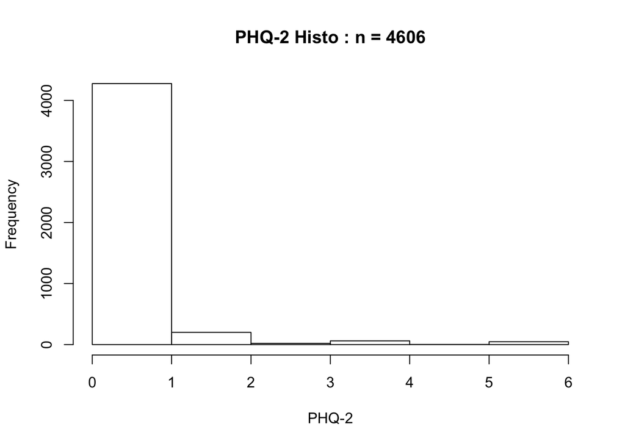

```r
####

#demographics and lab historgrams
#print histogram of phq-2/9s for people

hist(data_empi_acc_f_phq$PHQ.2[which(!is.na(data_empi_acc_f_phq$PHQ.2))], main = paste0("PHQ-2 Histo : n = ", length(which(!is.na(data_empi_acc_f_phq$PHQ.2)))), xlab = "PHQ-2", breaks = 8)
```

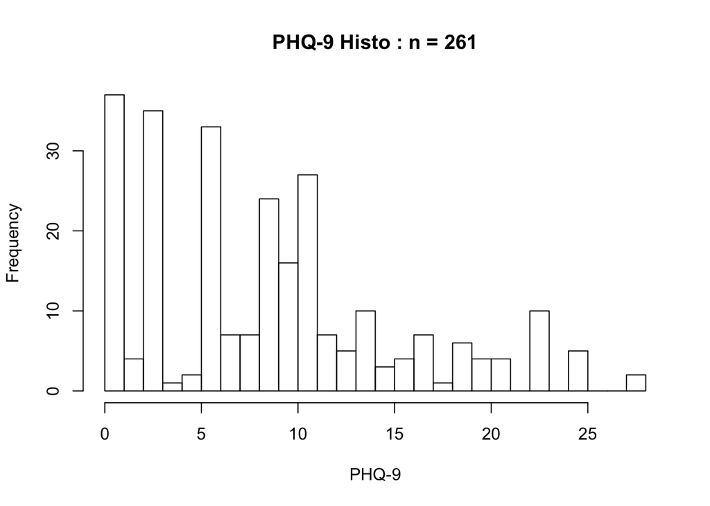

```r
hist(data_empi_acc_f_phq$PHQ.9[which(!is.na(data_empi_acc_f_phq$PHQ.9))], main = paste0("PHQ-9 Histo : n = ", length(which(!is.na(data_empi_acc_f_phq$PHQ.9)))), xlab = "PHQ-9", breaks = 30)
```

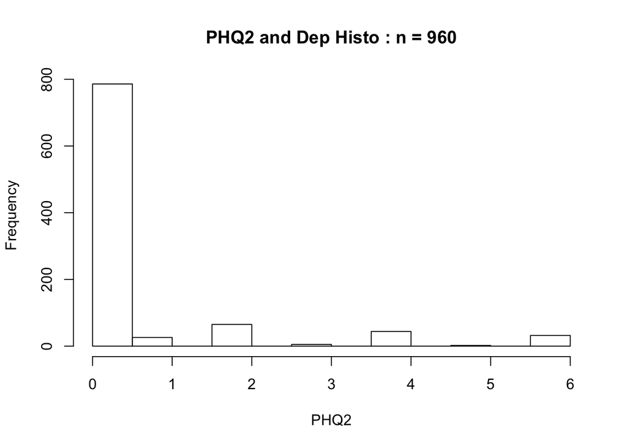

```r
#fcode histos
hist(dep_df$PHQ.2, main = paste0("PHQ2 and Dep Histo : n = ", num_phq2_and_dep), xlab = paste0("PHQ2"))
```

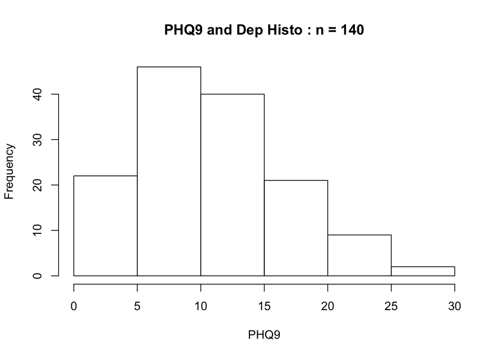

```r
hist(dep_df$PHQ.9,main = paste0("PHQ9 and Dep Histo : n = ", num_phq9_and_dep), xlab = paste0("PHQ9"))
```

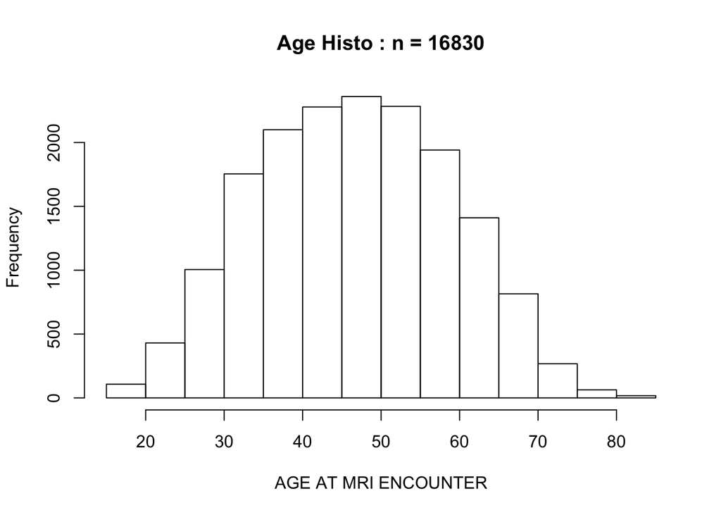

```r
###

#age histogram
hist(data_empi_acc_f_phq$MRI_ENC_AGE[which(!is.na(data_empi_acc_f_phq$MRI_ENC_AGE))], main = paste0("Age Histo : n = ", length(which(!is.na(data_empi_acc_f_phq$MRI_ENC_AGE)))), xlab = "AGE AT MRI ENCOUNTER")
```

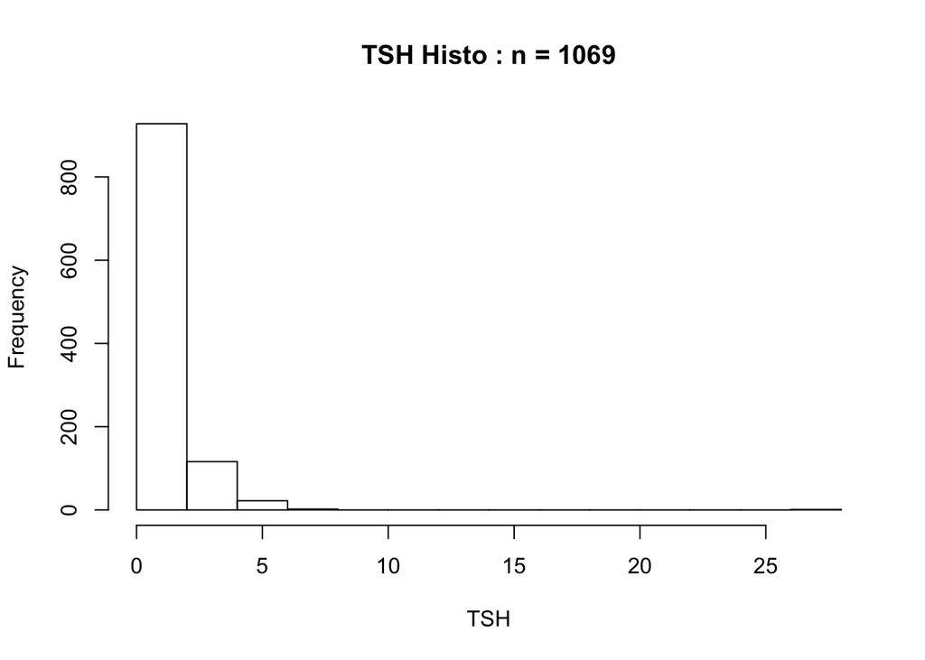

```r
#tsh
hist(data_empi_acc_f_phq$TSH[which(!is.na(data_empi_acc_f_phq$TSH))], main = paste0("TSH Histo : n = ", length(which(!is.na(data_empi_acc_f_phq$TSH)))), xlab = "TSH")
```

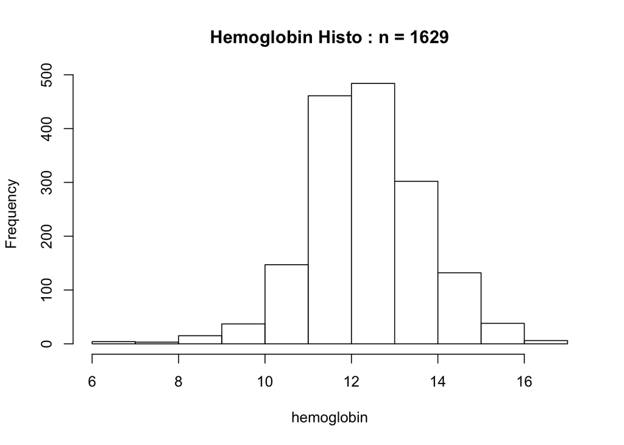

```r
#hemoglobin
hist(data_empi_acc_f_phq$hemoglobin[which(!is.na(data_empi_acc_f_phq$hemoglobin))], main = paste0("Hemoglobin Histo : n = ", length(which(!is.na(data_empi_acc_f_phq$hemoglobin)))), xlab = "hemoglobin")
```

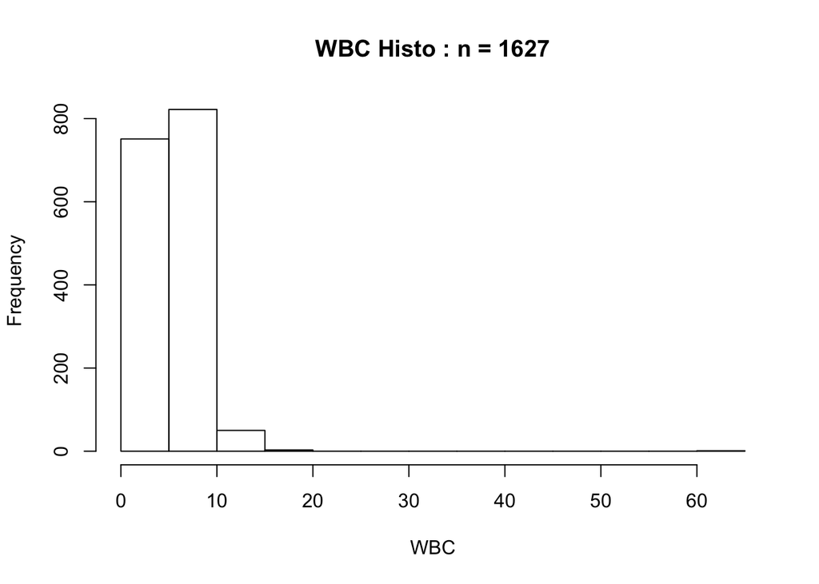

```r
#wbc
hist(data_empi_acc_f_phq$WBC[which(!is.na(data_empi_acc_f_phq$WBC))], main = paste0("WBC Histo : n = ", length(which(!is.na(data_empi_acc_f_phq$WBC)))), xlab = "WBC")
```

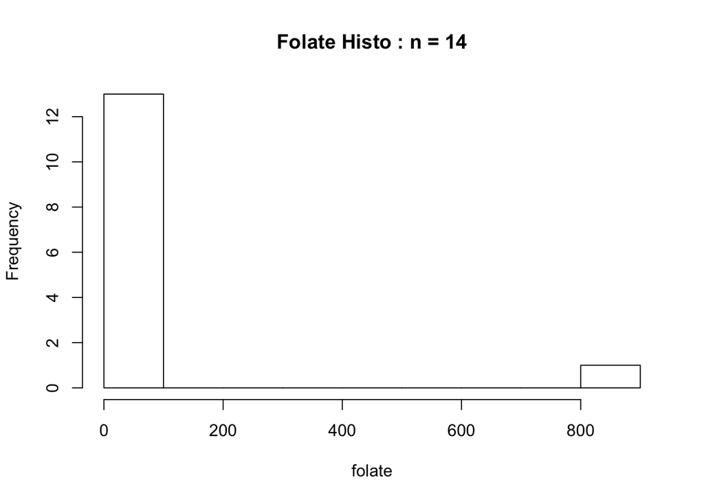

```r
#folate
hist(data_empi_acc_f_phq$FOLATE[which(!is.na(data_empi_acc_f_phq$FOLATE))], main = paste0("Folate Histo : n = ", length(which(!is.na(data_empi_acc_f_phq$FOLATE)))), xlab = "folate", breaks = 10)
```

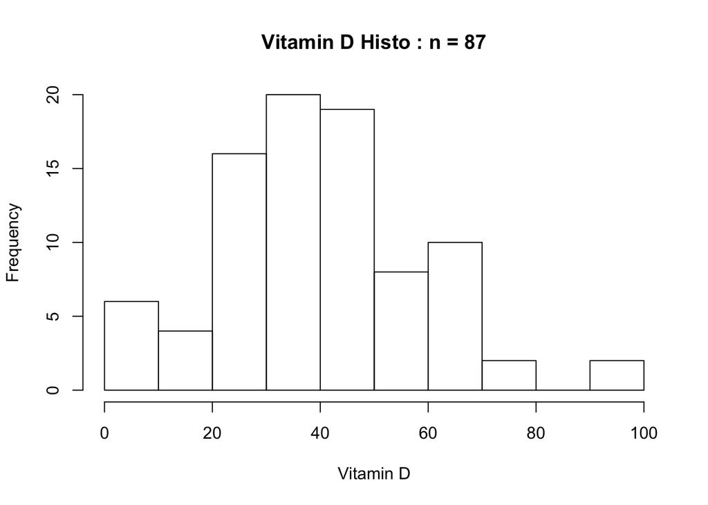

```r
#vitamin D
hist(data_empi_acc_f_phq$VitD[which(!is.na(data_empi_acc_f_phq$VitD))], main = paste0("Vitamin D Histo : n = ", length(which(!is.na(data_empi_acc_f_phq$VitD)))), xlab = "Vitamin D", breaks = 10)
```

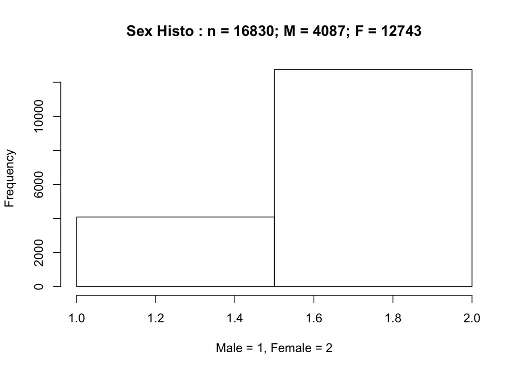

```r
#sex
hist(data_empi_acc_f_phq$sex_binarized[which(!is.na(data_empi_acc_f_phq$sex_binarized))],
     main = paste0("Sex Histo : n = ", length(which(!is.na(data_empi_acc_f_phq$sex_binarized))), "; M = ", length(which(data_empi_acc_f_phq$sex_binarized == 1)), "; F = ", length(which(data_empi_acc_f_phq$sex_binarized == 2)) ),
     xlab = "Male = 1, Female = 2",
     breaks = 2)
```

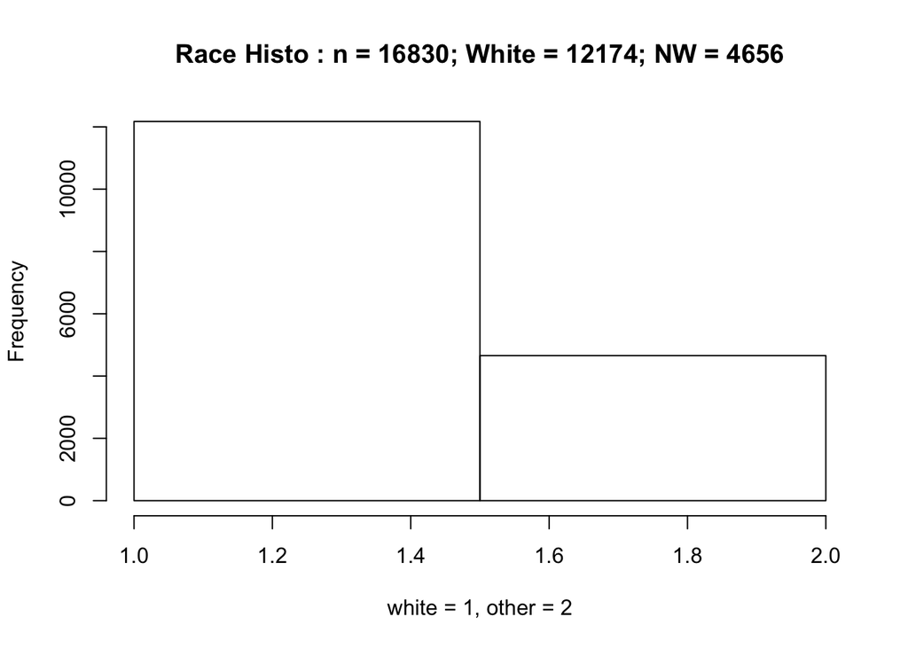

```r
#race
hist(data_empi_acc_f_phq$race_binarized[which(!is.na(data_empi_acc_f_phq$race_binarized))],
     main = paste0("Race Histo : n = ", length(which(!is.na(data_empi_acc_f_phq$race))), "; White = ", length(which(data_empi_acc_f_phq$race_binarized == 1)), "; NW = ", length(which(data_empi_acc_f_phq$race_binarized == 2))),
     xlab = "white = 1, other = 2",
     breaks = 2)
```

```r
#f-codes - people usually have BOTH icd9/10 or neither
```

```r
num_dep_phq2 <- length(which(!is.na(data_empi_acc_f_phq$PHQ.2) & (data_empi_acc_f_phq$PHQ.2 >= 3))) #n = 130
num_dep_phq9 <- length(which(!is.na(data_empi_acc_f_phq$PHQ.9) & (data_empi_acc_f_phq$PHQ.9 >= 5))) #n = 184; https://www.sciencedirect.com/science/article/pii/B9780128179338000293 recommends using cut point of 11
num_total_phq2 <-length(which(!is.na(data_empi_acc_f_phq$PHQ.2)))
num_total_phq9 <-length(which(!is.na(data_empi_acc_f_phq$PHQ.9)))
dep_total_phq_table <- data.frame(matrix(data = c(num_dep_phq2, num_dep_phq9, num_total_phq2, num_total_phq9), nrow = 2, ncol = 2))
names(dep_total_phq_table) <- c("dep", "healthy")
row.names(dep_total_phq_table) <- c("phq2", "phq9")
chisq_dep_phq2_v_phq9 <- chisq.test(dep_total_phq_table)
chisq_dep_phq2_v_phq9
```

```
##
##  Pearson's Chi-squared test with Yates' continuity correction
##
## data:  dep_total_phq_table
## X-squared = 1058, df = 1, p-value < 2.2e-16
```

```r
print("observed")
```

```
## [1] "observed"
```

```r
chisq_dep_phq2_v_phq9$observed
```

```
##      dep healthy
## phq2 130    4606
## phq9 184     261
```

```r
print("expected")
```

```
## [1] "expected"
```

```r
chisq_dep_phq2_v_phq9$expected
```

```
##           dep   healthy
## phq2 287.0303 4448.9697
## phq9  26.9697  418.0303
```

```r
print("residuals")
```

```
## [1] "residuals"
```

```r
chisq_dep_phq2_v_phq9$residuals
```

```
##            dep   healthy
## phq2 -9.268716  2.354256
## phq9 30.237469 -7.680325
```

```r
### looking at anyone with phq2s or 9s
males.phq2 <- phq2_subset[which(phq2_subset$SEX == "MALE"),] #n = 951, mean = 0.20
females.phq2 <- phq2_subset[which(phq2_subset$SEX == "FEMALE"),] #n = 3655, mean = 0.26
m_v_f_phq2 <- t.test(males.phq2$PHQ.2, females.phq2$PHQ.2) #p = 0.03 ***

males.phq9 <- phq9_subset[which(phq9_subset$SEX == "MALE"),] #n = 80, mean = 8.63
females.phq9 <- phq9_subset[which(phq9_subset$SEX == "FEMALE"),] #n = 181, mean = 9.13
m_v_f_phq9 <- t.test(males.phq9$PHQ.9, females.phq9$PHQ.9)

#### Looking at depressed group
## interstingly, not the 2:1 ratio we usually see in general world
## phq2 means suggest people are not depressed
## phq2 means suggest people meet criteria for mild depression

males_dep <- dep_df[(which(dep_df$SEX == "MALE")),] #n = 419/total(4087; 10%) F; mean PHQ2 = 0.61, mean PHQ9 = 13.05
females_dep <- dep_df[(which(dep_df$SEX == "FEMALE")),] #n = 1704/total(12743; 13%)total F; mean = 0.56; mean PHQ9 = 10.61
m_v_f_dep_phq2 <- t.test(males_dep$PHQ.2, females_dep$PHQ.2) #p = 0.66
m_v_f_dep_phq9 <- t.test(males_dep$PHQ.9, females_dep$PHQ.9) #p = 0.24

#chi sq comparing # of pts dx with depression in males vs females; col 1- male dep n, female dep n; col 2- male total n, female total n
### fascinating - only 12% of people even gave a dx of depression in their charts. More likely to have it if female than male; also phq2 mean only slightly higher in females.
num_dep_m <- dim(males_dep)[1] #n = 419
num_dep_f <-  dim(females_dep)[1]#n = 1704
num_total_m <- length(which(data_empi_acc_f_phq$SEX == "MALE")) #n = 4087
num_total_f <- length(which(data_empi_acc_f_phq$SEX == "FEMALE")) #n =
m_v_f_table <- data.frame(matrix(data = c(num_dep_m, num_dep_f, num_total_m, num_total_f), nrow = 2, ncol = 2))
names(m_v_f_table) <- c("dep", "total")
row.names(m_v_f_table) <- c("male", "female")
chisq_m_v_f_dist <- chisq.test(m_v_f_table) #p = 4 x 10^-6
chisq_m_v_f_dist
```

```
##
##  Pearson's Chi-squared test with Yates' continuity correction
##
## data:  m_v_f_table
## X-squared = 21.265, df = 1, p-value = 4e-06
```

```r
print("observed")
```

```
## [1] "observed"
```

```r
chisq_m_v_f_dist$observed
```

```
##         dep total
## male    419  4087
## female 1704 12743
```

```r
print("expected")
```

```
## [1] "expected"
```

```r
chisq_m_v_f_dist$expected
```

```
##              dep     total
## male    504.7348  4001.265
## female 1618.2652 12828.735
```

```r
print("residuals")
```

```
## [1] "residuals"
```

```r
chisq_m_v_f_dist$residuals
```

```
##              dep      total
## male   -3.816149  1.3553713
## female  2.131239 -0.7569463
```

```r
#chisq comparing # of
```

```r
#preprocessing - because these are sent


#load our df

#from Jan 2021 pull
data <- read.csv("/Users/eballer/BBL/msdepression/data/dac/investigatingdepressioninmspatients.csv", header = TRUE, stringsAsFactors = FALSE, na.strings = c("NULL"), sep =",")

ms_providers <- c("MARKOWITZ, CLYDE E.", "JACOBS, DINA A.", "WILLIAMSON, ERIC MICHAEL-LEE", "BERGER, JOSEPH ROBERT", "BERGER DO, JOSEPH", "PRUITT, AMY A.", "KOLSON, DENNIS L.", "CHAHIN, SALIM", "NARULA, SONA", "BAR-OR, AMIT")


#keep people with MS providers
data_empi_acc_f_phq <- data[which(data$Provider %in% ms_providers),] #n = 17067

#keep people with ICD10 code G35 (this is the same # as people with IC9 - 340)
data_empi_acc_f_phq <- data_empi_acc_f_phq[grep("G35", data_empi_acc_f_phq$ICD10),] #n = 16830
table(data_empi_acc_f_phq$Provider)
```

```
##
##                 BAR-OR, AMIT            BERGER DO, JOSEPH
##                           93                            1
##        BERGER, JOSEPH ROBERT                CHAHIN, SALIM
##                         1818                          260
##              JACOBS, DINA A.            KOLSON, DENNIS L.
##                         4765                          643
##          MARKOWITZ, CLYDE E.                 NARULA, SONA
##                         6245                          274
##               PRUITT, AMY A. WILLIAMSON, ERIC MICHAEL-LEE
##                         1372                         1359
```

```r
##########################
### some preprocessing ###
##########################

#make accession # and lab findings into integer type, contained in row 28:42, Margin=2 to work on columns
data_empi_acc_f_phq$ACCESSION_NUM <- as.integer(data_empi_acc_f_phq$ACCESSION_NUM)
data_empi_acc_f_phq[27:29] <- apply(X = data_empi_acc_f_phq[27:29], FUN = as.integer, MARGIN = 2)
data_empi_acc_f_phq[31:45] <- apply(X = data_empi_acc_f_phq[31:45], FUN = as.integer, MARGIN = 2)
```

```r
data_empi_acc_f_phq$sex_binarized <- ifelse(data_empi_acc_f_phq$SEX == "MALE", 1, 2)
data_empi_acc_f_phq$race_binarized <- ifelse(data_empi_acc_f_phq$RACE == "WHITE", 1, 2)

########################################
#### Start counting / making subsets ###
########################################

# number of unique scanners and scans
print(paste0("Number of unique procedure names (ie. MRI Head w/out contrast; MRI Source Images): ",  length(unique(data_empi_acc_f_phq$PROC_CODE)))) #n = 10
```

```
## [1] "Number of unique procedure names (ie. MRI Head w/out contrast; MRI Source Images): 10"
```

```r
print(paste0("Number of unique department names (ie. RAD HUP PCAM Ground): ",  length(unique(data_empi_acc_f_phq$DEPARTMENT_NAME)))) #n = 3
```

```
## [1] "Number of unique department names (ie. RAD HUP PCAM Ground): 3"
```

```r
print(paste0("Number of unique modalities (ie. HUP PCAM GR MR4 3T; MR6 3T): ",  length(unique(data_empi_acc_f_phq$MODALITY)))) #n = 11
```

```
## [1] "Number of unique modalities (ie. HUP PCAM GR MR4 3T; MR6 3T): 11"
```

```r
print(paste0("Number of unique accession #s n= ", length(unique(data_empi_acc_f_phq$ACCESSION_NUM)))) # n = 16830
```

```
## [1] "Number of unique accession #s n= 16830"
```

```r
print(paste0("Number of unique EMPIS n = ", length(unique(data_empi_acc_f_phq$EMPI)))) #n = 3737
```

```
## [1] "Number of unique EMPIS n = 3737"
```

```r
#### PHQ-2 and PHQ-9 summaries

#looking at just people with phq-2 and 9
phq2_subset <- data_empi_acc_f_phq[which(!is.na(data_empi_acc_f_phq$PHQ.2)),] #n=4606

phq9_subset <- data_empi_acc_f_phq[which(!is.na(data_empi_acc_f_phq$PHQ.9)),] #n= 261

#phq-2;
print(paste0("N PHQ-2 = ", sum(!is.na(data_empi_acc_f_phq$PHQ.2)), "; n = ", length(which(phq2_subset$PHQ.2 >= 3)), " meeting criteria for depression (PHQ2) >= 3")) #n = 4606
```

```
## [1] "N PHQ-2 = 4606; n = 130 meeting criteria for depression (PHQ2) >= 3"
```

```r
#phq-9
print(paste0("N PHQ-9 = ", sum(!is.na(data_empi_acc_f_phq$PHQ.9)), "; noDep/mild/mod/mod-severe/severe = ",
             length(which(phq9_subset$PHQ.9 < 5)), "/",
             length(which(phq9_subset$PHQ.9 >= 5 & phq9_subset$PHQ.9 < 10)), "/",
             length(which(phq9_subset$PHQ.9 >= 10 & phq9_subset$PHQ.9 < 15)), "/",
             length(which(phq9_subset$PHQ.9 >= 15 & phq9_subset$PHQ.9 < 20)), "/",
             length(which(phq9_subset$PHQ.9 >= 20)))) #n = 261
```

```
## [1] "N PHQ-9 = 261; noDep/mild/mod/mod-severe/severe = 77/73/65/21/25"
```

```r
#both phq2 and 9

num_both_phq2_and_9 <- length(which(!is.na(data_empi_acc_f_phq$PHQ.2) & !is.na(data_empi_acc_f_phq$PHQ.9)))
print(paste0("num people with both phq2 and 9 = ", num_both_phq2_and_9)) #n = 0
```

```
## [1] "num people with both phq2 and 9 = 0"
```

```r
#Number of unique EMPIs in phq2/phq9 subsets
unique_phq2_empis <- length(unique(phq2_subset$EMPI)) #n=966
print(paste0("N with phq2 (Unique EMPI) n = ", unique_phq2_empis, " out of ", dim(phq2_subset)[1], "; n - ", length(unique(phq2_subset$EMPI[phq2_subset$PHQ.2 >= 3])), " meeting criteria for depression (PHQ2) >= 3")) #n = 4606
```

```
## [1] "N with phq2 (Unique EMPI) n = 899 out of 4606; n - 32 meeting criteria for depression (PHQ2) >= 3"
```

```r
unique_phq9_empis <- length(unique(phq9_subset$EMPI)) #n=76
print(paste0("N with phq9 (Unique EMPI) n = ", unique_phq9_empis, " out of ", dim(phq9_subset)[1], "; noDep/mild/mod/mod-severe/severe = ",
             length(unique(phq9_subset$EMPI[phq9_subset$PHQ.9 < 5])), "/",
             length(unique(phq9_subset$EMPI[(phq9_subset$PHQ.9 >= 5 & phq9_subset$PHQ.9 < 10)])), "/",
             length(unique(phq9_subset$EMPI[(phq9_subset$PHQ.9 >= 10 & phq9_subset$PHQ.9 < 15)])), "/",
             length(unique(phq9_subset$EMPI[(phq9_subset$PHQ.9 >= 15 & phq9_subset$PHQ.9 < 20)])), "/",
             length(unique(phq9_subset$EMPI[phq9_subset$PHQ.9 >= 20]))))
```

```
## [1] "N with phq9 (Unique EMPI) n = 68 out of 261; noDep/mild/mod/mod-severe/severe = 18/16/18/8/8"
```

```r
#### ICD 9/10 for Psychosis
psychosis_df <- data_empi_acc_f_phq[grep("F2", data_empi_acc_f_phq$ICD10),] #n = 2123
num_psychosis <- dim(psychosis_df)[1]
unique_empi <- which(unique(data_empi_acc_f_phq$EMPI) %in% data_empi_acc_f_phq$EMPI) #index of the locations of unique empis; n = 3885
num_unique_EMPI_and_psychosis <- length(unique(psychosis_df$EMPI)) #n = 493

print(paste0("N with ICD 9/10 codes for psychosis = ", num_psychosis))
```

```
## [1] "N with ICD 9/10 codes for psychosis = 0"
```

```r
print(paste0("N with ICD 9/10 codes for psychosis and unique EMPI = ", num_unique_EMPI_and_psychosis, " out of ", dim(data_empi_acc_f_phq)[1]))
```

```
## [1] "N with ICD 9/10 codes for psychosis and unique EMPI = 0 out of 16830"
```

```r
##### PHQ2 or 9 + ICD 9/10 psychosis
num_phq2_and_psychosis <- length(which(!is.na(psychosis_df$PHQ.2))) #n = 960
print(paste0("N with ICD 9/10 codes for psychosis and phq2 (ALL SCANS) = ", num_phq2_and_psychosis, " out of ", dim(psychosis_df)[1]))
```

```
## [1] "N with ICD 9/10 codes for psychosis and phq2 (ALL SCANS) = 0 out of 0"
```

```r
num_phq9_and_psychosis <- length(which(!is.na(psychosis_df$PHQ.9))) #n=140
print(paste0("N with ICD 9/10 codes for psychosis and phq9 (ALL SCANS) = ", num_phq9_and_psychosis, " out of ", dim(psychosis_df)[1]))
```

```
## [1] "N with ICD 9/10 codes for psychosis and phq9 (ALL SCANS) = 0 out of 0"
```

```r
#phq-2;
print(paste0("N psychosis + PHQ-2 = ", sum(!is.na(psychosis_df$PHQ.2)), "; n = ", length(which(psychosis_df$PHQ.2 >= 3)), " meeting criteria for psychosis (PHQ2) >= 3")) #n = 4606
```

```
## [1] "N psychosis + PHQ-2 = 0; n = 0 meeting criteria for psychosis (PHQ2) >= 3"
```

```r
#phq-9
print(paste0("N psychosis + PHQ-9 = ", sum(!is.na(psychosis_df$PHQ.9)), "; nopsychosis/mild/mod/mod-severe/severe = ",
             length(which(psychosis_df$PHQ.9 < 5)), "/",
             length(which(psychosis_df$PHQ.9 >= 5 & psychosis_df$PHQ.9 < 10)), "/",
             length(which(psychosis_df$PHQ.9 >= 10 & psychosis_df$PHQ.9 < 15)), "/",
             length(which(psychosis_df$PHQ.9 >= 15 & psychosis_df$PHQ.9 < 20)), "/",
             length(which(psychosis_df$PHQ.9 >= 20)))) #n = 261
```

```
## [1] "N psychosis + PHQ-9 = 0; nopsychosis/mild/mod/mod-severe/severe = 0/0/0/0/0"
```

```r
#### # unique people with psychosis dx and phq2/9 -> working on this
psychosis_dx_phq2_unique <- length(unique(psychosis_df$EMPI[!is.na(psychosis_df$PHQ.2)])) #n = 201
print(paste0("N with ICD 9/10 codes for psychosis and phq2 (unique) = ", psychosis_dx_phq2_unique, " out of ", dim(psychosis_df)[1]))
```

```
## [1] "N with ICD 9/10 codes for psychosis and phq2 (unique) = 0 out of 0"
```

```r
psychosis_dx_phq9_unique <- length(unique(psychosis_df$EMPI[!is.na(psychosis_df$PHQ.9)])) #n = 43
print(paste0("N with ICD 9/10 codes for psychosis and phq9 (unique) = ", psychosis_dx_phq9_unique, " out of ", dim(psychosis_df)[1]))
```

```
## [1] "N with ICD 9/10 codes for psychosis and phq9 (unique) = 0 out of 0"
```

```r
####


#### ICD 9/10 for Healthy Group
healthy_df <- data_empi_acc_f_phq[(-grep("F3", data_empi_acc_f_phq$ICD10)),] #n = 14707
num_healthy <- dim(healthy_df)[1]
unique_empi <- which(unique(healthy_df$EMPI) %in% healthy_df$EMPI) #index of the locations of unique empis; n = 3244
num_unique_EMPI_and_healthy <- length(unique(healthy_df$EMPI)) #n = 3244

print(paste0("N without psychosis/ICD 9/10 codes for healthy = ", num_healthy))
```

```
## [1] "N without psychosis/ICD 9/10 codes for healthy = 14707"
```

```r
print(paste0("N without psychosis/ ICD 9/10 codes for healthy and unique EMPI = ", num_unique_EMPI_and_healthy, " out of ", dim(healthy_df)[1]))
```

```
## [1] "N without psychosis/ ICD 9/10 codes for healthy and unique EMPI = 3244 out of 14707"
```

```r
##### PHQ2 or 9 + No psychosis ICD9/10
num_phq2_and_healthy <- length(which(!is.na(healthy_df$PHQ.2))) #n = 3646
print(paste0("N without psychosis/ ICD 9/10 codes for healthy and phq2 (ALL SCANS) = ", num_phq2_and_healthy, " out of ", dim(healthy_df)[1]))
```

```
## [1] "N without psychosis/ ICD 9/10 codes for healthy and phq2 (ALL SCANS) = 3646 out of 14707"
```

```r
#phq-2;
print(paste0("N healthy w/PHQ-2 = ", sum(!is.na(healthy_df$PHQ.2)), "; n = ", length(which(healthy_df$PHQ.2 >= 3)), " meeting criteria for psychosis (PHQ2) >= 3")) #n = 47
```

```
## [1] "N healthy w/PHQ-2 = 3646; n = 47 meeting criteria for psychosis (PHQ2) >= 3"
```

```r
num_phq9_and_healthy <- length(which(!is.na(healthy_df$PHQ.9))) #n=121
print(paste0("N without psychosis/ ICD 9/10 codes for healthy and phq9 (ALL SCANS) = ", num_phq9_and_healthy, " out of ", dim(healthy_df)[1]))
```

```
## [1] "N without psychosis/ ICD 9/10 codes for healthy and phq9 (ALL SCANS) = 121 out of 14707"
```

```r
#phq-9
print(paste0("N healthy w/PHQ-9 = ", sum(!is.na(healthy_df$PHQ.9)), "; nopsychosis/mild/mod/mod-severe/severe = ",
             length(which(healthy_df$PHQ.9 < 5)), "/",
             length(which(healthy_df$PHQ.9 >= 5 & healthy_df$PHQ.9 < 10)), "/",
             length(which(healthy_df$PHQ.9 >= 10 & healthy_df$PHQ.9 < 15)), "/",
             length(which(healthy_df$PHQ.9 >= 15 & healthy_df$PHQ.9 < 20)), "/",
             length(which(healthy_df$PHQ.9 >= 20)))) #n = 55/34/21/1/10
```

```
## [1] "N healthy w/PHQ-9 = 121; nopsychosis/mild/mod/mod-severe/severe = 55/34/21/1/10"
```

```r
#### # unique people without psychosis dx and phq2/9
psychosis_dx_phq2_unique <- length(unique(healthy_df$EMPI[!is.na(healthy_df$PHQ.2)])) #n = 201
print(paste0("N without psychosis/ ICD 9/10 codes for healthy and phq2 (unique) = ", psychosis_dx_phq2_unique, " out of ", dim(healthy_df)[1]))
```

```
## [1] "N without psychosis/ ICD 9/10 codes for healthy and phq2 (unique) = 698 out of 14707"
```

```r
psychosis_dx_phq9_unique <- length(unique(healthy_df$EMPI[!is.na(healthy_df$PHQ.9)])) #n = 43
print(paste0("N without psychosis/ ICD 9/10 codes for healthy and phq9 (unique) = ", psychosis_dx_phq9_unique, " out of ", dim(healthy_df)[1]))
```

```
## [1] "N without psychosis/ ICD 9/10 codes for healthy and phq9 (unique) = 25 out of 14707"
```

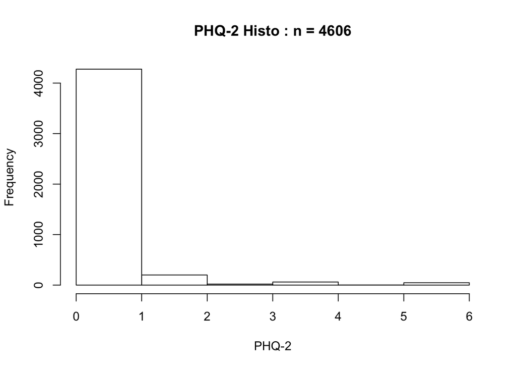

```r
####

#demographics and lab historgrams
#print histogram of phq-2/9s for people

hist(data_empi_acc_f_phq$PHQ.2[which(!is.na(data_empi_acc_f_phq$PHQ.2))], main = paste0("PHQ-2 Histo : n = ", length(which(!is.na(data_empi_acc_f_phq$PHQ.2)))), xlab = "PHQ-2", breaks = 8)
```

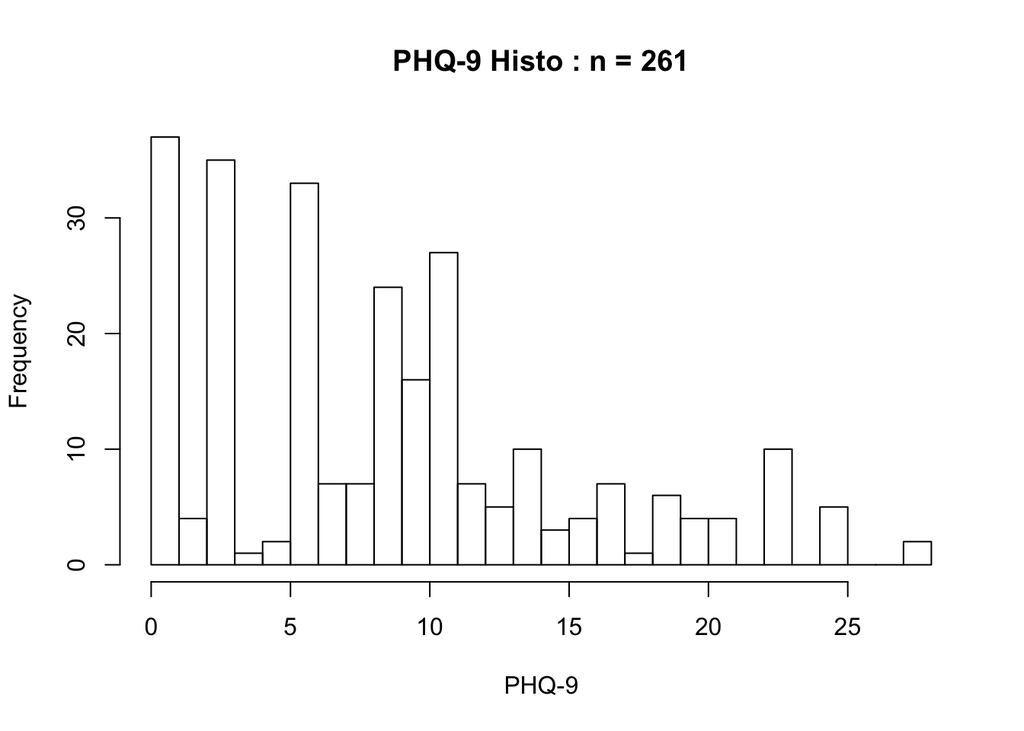

```r
hist(data_empi_acc_f_phq$PHQ.9[which(!is.na(data_empi_acc_f_phq$PHQ.9))], main = paste0("PHQ-9 Histo : n = ", length(which(!is.na(data_empi_acc_f_phq$PHQ.9)))), xlab = "PHQ-9", breaks = 30)
```

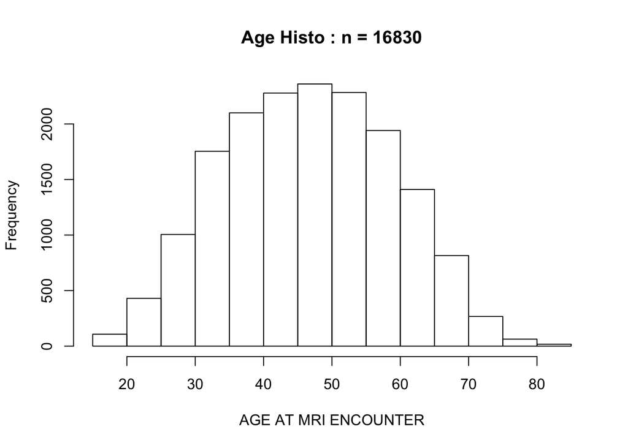

```r
#fcode histos - no one with it at this time.
#hist(psychosis_df$PHQ.2, main = paste0("PHQ2 and psychosis Histo : n = ", num_phq2_and_psychosis), xlab = paste0("PHQ2"))

#hist(psychosis_df$PHQ.9,main = paste0("PHQ9 and psychosis Histo : n = ", num_phq9_and_psychosis), xlab = paste0("PHQ9"))

###

#age histogram
hist(data_empi_acc_f_phq$MRI_ENC_AGE[which(!is.na(data_empi_acc_f_phq$MRI_ENC_AGE))], main = paste0("Age Histo : n = ", length(which(!is.na(data_empi_acc_f_phq$MRI_ENC_AGE)))), xlab = "AGE AT MRI ENCOUNTER")
```

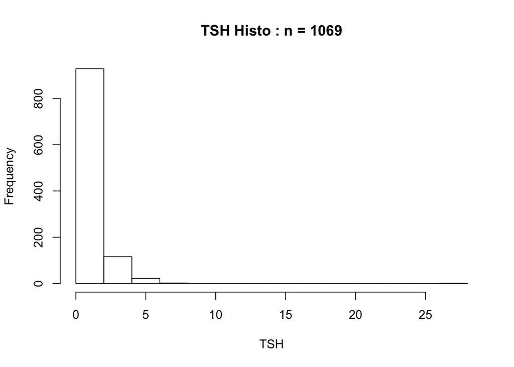

```r
#tsh
hist(data_empi_acc_f_phq$TSH[which(!is.na(data_empi_acc_f_phq$TSH))], main = paste0("TSH Histo : n = ", length(which(!is.na(data_empi_acc_f_phq$TSH)))), xlab = "TSH")
```

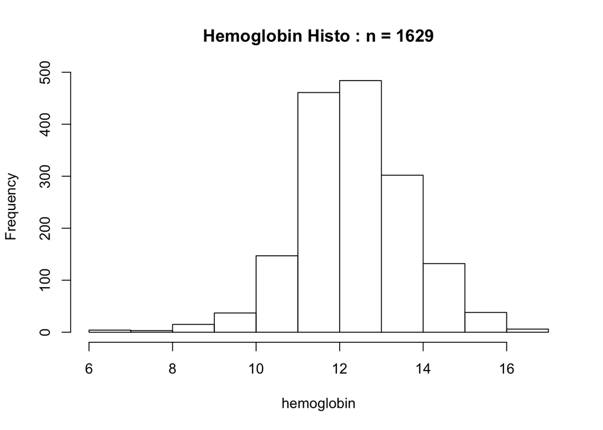

```r
#hemoglobin
hist(data_empi_acc_f_phq$hemoglobin[which(!is.na(data_empi_acc_f_phq$hemoglobin))], main = paste0("Hemoglobin Histo : n = ", length(which(!is.na(data_empi_acc_f_phq$hemoglobin)))), xlab = "hemoglobin")
```

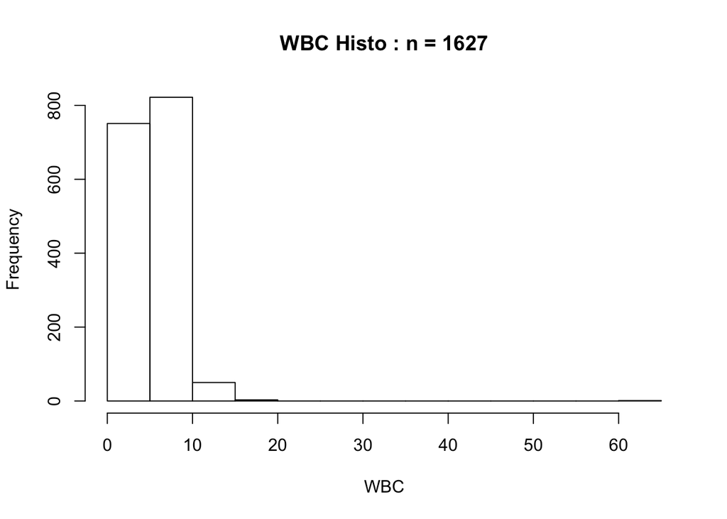

```r
#wbc
hist(data_empi_acc_f_phq$WBC[which(!is.na(data_empi_acc_f_phq$WBC))], main = paste0("WBC Histo : n = ", length(which(!is.na(data_empi_acc_f_phq$WBC)))), xlab = "WBC")
```

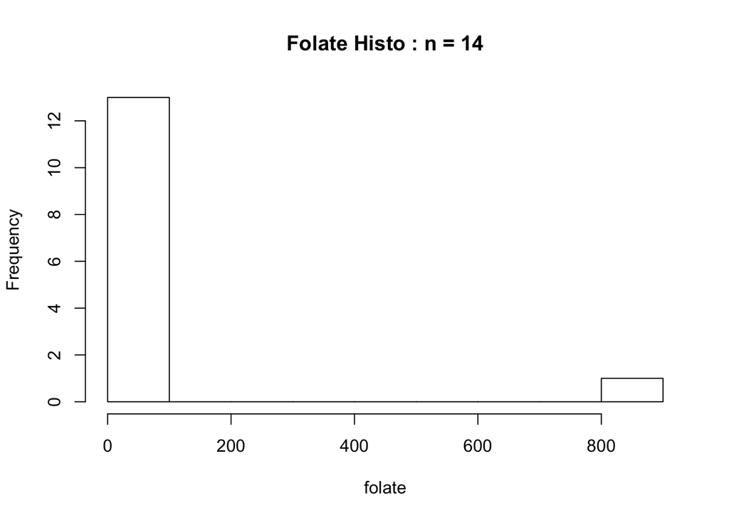

```r
#folate
hist(data_empi_acc_f_phq$FOLATE[which(!is.na(data_empi_acc_f_phq$FOLATE))], main = paste0("Folate Histo : n = ", length(which(!is.na(data_empi_acc_f_phq$FOLATE)))), xlab = "folate", breaks = 10)
```

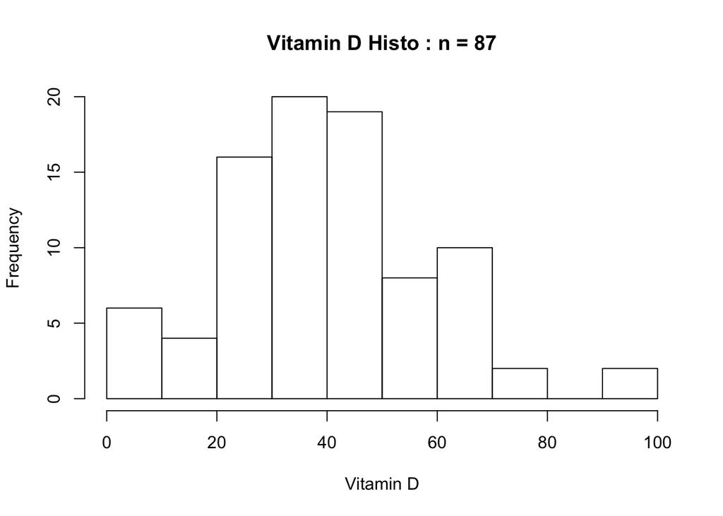

```r
#vitamin D
hist(data_empi_acc_f_phq$VitD[which(!is.na(data_empi_acc_f_phq$VitD))], main = paste0("Vitamin D Histo : n = ", length(which(!is.na(data_empi_acc_f_phq$VitD)))), xlab = "Vitamin D", breaks = 10)
```

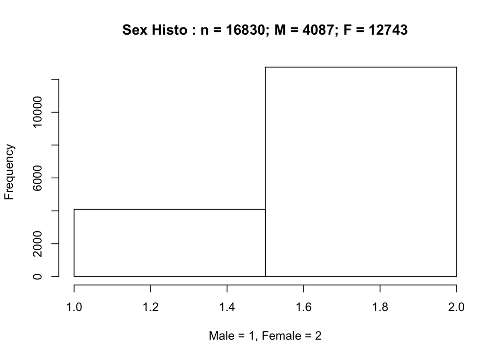

```r
#sex
hist(data_empi_acc_f_phq$sex_binarized[which(!is.na(data_empi_acc_f_phq$sex_binarized))],
     main = paste0("Sex Histo : n = ", length(which(!is.na(data_empi_acc_f_phq$sex_binarized))), "; M = ", length(which(data_empi_acc_f_phq$sex_binarized == 1)), "; F = ", length(which(data_empi_acc_f_phq$sex_binarized == 2)) ),
     xlab = "Male = 1, Female = 2",
     breaks = 2)
```

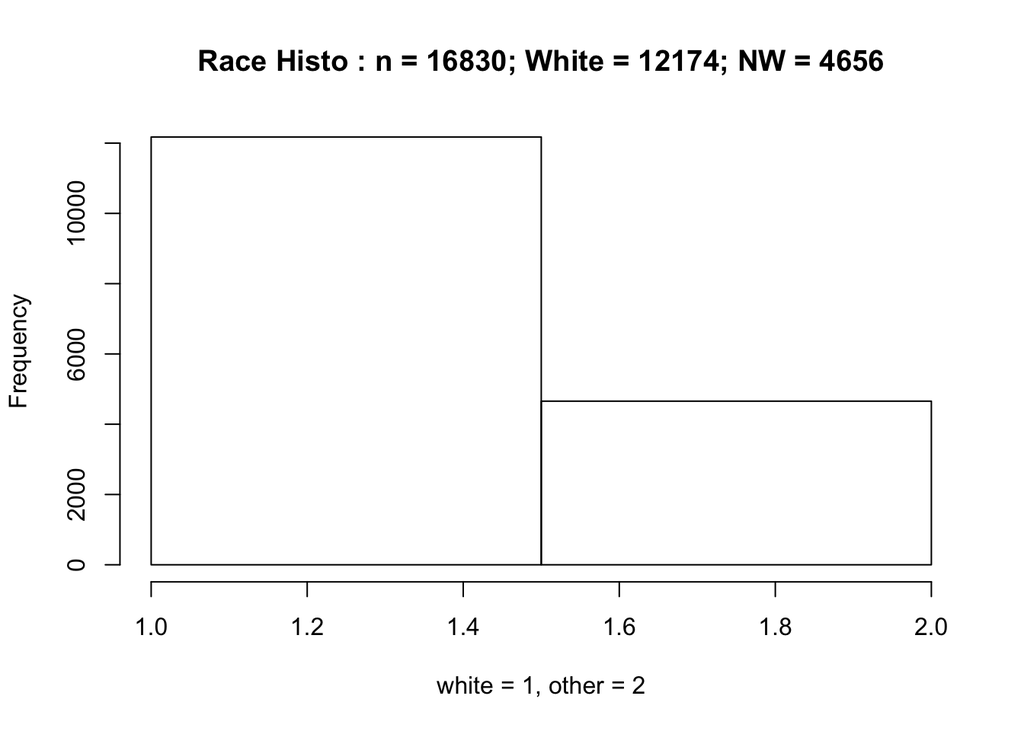

```r
#race
hist(data_empi_acc_f_phq$race_binarized[which(!is.na(data_empi_acc_f_phq$race_binarized))],
     main = paste0("Race Histo : n = ", length(which(!is.na(data_empi_acc_f_phq$race))), "; White = ", length(which(data_empi_acc_f_phq$race_binarized == 1)), "; NW = ", length(which(data_empi_acc_f_phq$race_binarized == 2))),
     xlab = "white = 1, other = 2",
     breaks = 2)
```

```r
#f-codes - people usually have BOTH icd9/10 or neither
```

```r
##### checking to see whether we have clinical data for patients who have already been segmented as of 5/4/2021
### had to do some parsing of tim's spreadsheet: /Users/eballer/BBL/msdepression/data/insurance_images_for_depression.csv
### used the following commands to extract the empi and the date -> in tim's they are in the format sub-***** and ses-YYYYMMDD

## more insurance_images_for_depression.csv | cut -f1 -d ','| perl -pe 's/sub-(.*)/$1/' > tim_empi
## more insurance_images_for_depression.csv | cut -f2 -d ','| perl -pe 's/ses-(....)(..)(..)/$2\/$3\/$1/' > tim_dates
## more tim_dates | perl -pe 's/(.*)20(..)/$1$2/' | perl -pe 's/(0)(.)\/(.*)\/(.*)/$2\/$3\/$4/' | perl -pe 's/(.*)\/(0)(.*)\/(.*)/$1\/$3\/$4/' > tim_dates_no_zero_pad

segmented <- read.csv("/Users/eballer/BBL/msdepression/data/insurance_images_for_depression_with_accession.csv", header = F, sep = ",") #n = 4468
names(segmented) <- c("EMPI", "EXAM_DATE", "SES", "ACCESSION_NUM")


#look at the overlap of EMPIs. Won't be able to actually check the matching of scan to person without either accession #s or changing the format of the date.
number_of_people_in_tims_group_that_are_also_in_mine <- length(which(segmented$ACCESSION_NUM %in% data_empi_acc_f_phq$ACCESSION_NUM)) #2919
overlap_group <- data_empi_acc_f_phq[which(data_empi_acc_f_phq$ACCESSION_NUM %in% segmented$ACCESSION_NUM),]

#### PHQ-2 and PHQ-9 summaries

#looking at just people with phq-2 and 9
phq2_subset <- overlap_group[which(!is.na(overlap_group$PHQ.2)),] #n=4606

phq9_subset <- overlap_group[which(!is.na(overlap_group$PHQ.9)),] #n= 261

#phq-2;
print(paste0("N PHQ-2 = ", sum(!is.na(overlap_group$PHQ.2)), "; n = ", length(which(phq2_subset$PHQ.2 >= 3)), " meeting criteria for depression (PHQ2) >= 3")) #n = 4606
```

```
## [1] "N PHQ-2 = 970; n = 31 meeting criteria for depression (PHQ2) >= 3"
```

```r
#phq-9
print(paste0("N PHQ-9 = ", sum(!is.na(overlap_group$PHQ.9)), "; noDep/mild/mod/mod-severe/severe = ",
             length(which(phq9_subset$PHQ.9 < 5)), "/",
             length(which(phq9_subset$PHQ.9 >= 5 & phq9_subset$PHQ.9 < 10)), "/",
             length(which(phq9_subset$PHQ.9 >= 10 & phq9_subset$PHQ.9 < 15)), "/",
             length(which(phq9_subset$PHQ.9 >= 15 & phq9_subset$PHQ.9 < 20)), "/",
             length(which(phq9_subset$PHQ.9 >= 20)))) #n = 261
```

```
## [1] "N PHQ-9 = 39; noDep/mild/mod/mod-severe/severe = 12/13/8/3/3"
```

```r
#both phq2 and 9

num_both_phq2_and_9 <- length(which(!is.na(overlap_group$PHQ.2) & !is.na(overlap_group$PHQ.9)))
print(paste0("num people with both phq2 and 9 = ", num_both_phq2_and_9)) #n = 0
```

```
## [1] "num people with both phq2 and 9 = 0"
```

```r
#Number of unique EMPIs in phq2/phq9 subsets
unique_phq2_empis <- length(unique(phq2_subset$EMPI)) #n=966
print(paste0("N with phq2 (Unique EMPI) n = ", unique_phq2_empis, " out of ", dim(phq2_subset)[1], "; n - ", length(unique(phq2_subset$EMPI[phq2_subset$PHQ.2 >= 3])), " meeting criteria for depression (PHQ2) >= 3")) #n = 4606
```

```
## [1] "N with phq2 (Unique EMPI) n = 317 out of 970; n - 9 meeting criteria for depression (PHQ2) >= 3"
```

```r
unique_phq9_empis <- length(unique(phq9_subset$EMPI)) #n=76
print(paste0("N with phq9 (Unique EMPI) n = ", unique_phq9_empis, " out of ", dim(phq9_subset)[1], "; noDep/mild/mod/mod-severe/severe = ",
             length(unique(phq9_subset$EMPI[phq9_subset$PHQ.9 < 5])), "/",
             length(unique(phq9_subset$EMPI[(phq9_subset$PHQ.9 >= 5 & phq9_subset$PHQ.9 < 10)])), "/",
             length(unique(phq9_subset$EMPI[(phq9_subset$PHQ.9 >= 10 & phq9_subset$PHQ.9 < 15)])), "/",
             length(unique(phq9_subset$EMPI[(phq9_subset$PHQ.9 >= 15 & phq9_subset$PHQ.9 < 20)])), "/",
             length(unique(phq9_subset$EMPI[phq9_subset$PHQ.9 >= 20]))))
```

```
## [1] "N with phq9 (Unique EMPI) n = 17 out of 39; noDep/mild/mod/mod-severe/severe = 3/6/3/3/2"
```

```r
#### ICD 9/10 for Depression
dep_df <- overlap_group[grep("F3", overlap_group$ICD10),] #n = 2123
num_depression <- dim(dep_df)[1]
unique_empi <- which(unique(overlap_group$EMPI) %in% overlap_group$EMPI) #index of the locations of unique empis; n = 3885
num_unique_EMPI_and_dep <- length(unique(dep_df$EMPI)) #n = 493

print(paste0("N with ICD 9/10 codes for depression = ", num_depression))
```

```
## [1] "N with ICD 9/10 codes for depression = 391"
```

```r
print(paste0("N with ICD 9/10 codes for depression and unique EMPI = ", num_unique_EMPI_and_dep, " out of ", dim(overlap_group)[1]))
```

```
## [1] "N with ICD 9/10 codes for depression and unique EMPI = 145 out of 2915"
```

```r
##### PHQ2 or 9 + ICD 9/10 Depression
num_phq2_and_dep <- length(which(!is.na(dep_df$PHQ.2))) #n = 960
print(paste0("N with ICD 9/10 codes for depression and phq2 (ALL SCANS) = ", num_phq2_and_dep, " out of ", dim(dep_df)[1]))
```

```
## [1] "N with ICD 9/10 codes for depression and phq2 (ALL SCANS) = 191 out of 391"
```

```r
num_phq9_and_dep <- length(which(!is.na(dep_df$PHQ.9))) #n=140
print(paste0("N with ICD 9/10 codes for depression and phq9 (ALL SCANS) = ", num_phq9_and_dep, " out of ", dim(dep_df)[1]))
```

```
## [1] "N with ICD 9/10 codes for depression and phq9 (ALL SCANS) = 23 out of 391"
```

```r
#phq-2;
print(paste0("N dep + PHQ-2 = ", sum(!is.na(dep_df$PHQ.2)), "; n = ", length(which(dep_df$PHQ.2 >= 3)), " meeting criteria for depression (PHQ2) >= 3")) #n = 4606
```

```
## [1] "N dep + PHQ-2 = 191; n = 15 meeting criteria for depression (PHQ2) >= 3"
```

```r
#phq-9
print(paste0("N dep + PHQ-9 = ", sum(!is.na(dep_df$PHQ.9)), "; noDep/mild/mod/mod-severe/severe = ",
             length(which(dep_df$PHQ.9 < 5)), "/",
             length(which(dep_df$PHQ.9 >= 5 & dep_df$PHQ.9 < 10)), "/",
             length(which(dep_df$PHQ.9 >= 10 & dep_df$PHQ.9 < 15)), "/",
             length(which(dep_df$PHQ.9 >= 15 & dep_df$PHQ.9 < 20)), "/",
             length(which(dep_df$PHQ.9 >= 20)))) #n = 261
```

```
## [1] "N dep + PHQ-9 = 23; noDep/mild/mod/mod-severe/severe = 3/10/6/3/1"
```

```r
#### # unique people with dep dx and phq2/9 -> working on this
dep_dx_phq2_unique <- length(unique(dep_df$EMPI[!is.na(dep_df$PHQ.2)])) #n = 201
print(paste0("N with ICD 9/10 codes for depression and phq2 (unique) = ", dep_dx_phq2_unique, " out of ", dim(dep_df)[1]))
```

```
## [1] "N with ICD 9/10 codes for depression and phq2 (unique) = 71 out of 391"
```

```r
dep_dx_phq9_unique <- length(unique(dep_df$EMPI[!is.na(dep_df$PHQ.9)])) #n = 43
print(paste0("N with ICD 9/10 codes for depression and phq9 (unique) = ", dep_dx_phq9_unique, " out of ", dim(dep_df)[1]))
```

```
## [1] "N with ICD 9/10 codes for depression and phq9 (unique) = 11 out of 391"
```

```r
####


#### ICD 9/10 for Healthy Group
healthy_df <- overlap_group[(-grep("F3", overlap_group$ICD10)),] #n = 14707
num_healthy <- dim(healthy_df)[1]
unique_empi <- which(unique(healthy_df$EMPI) %in% healthy_df$EMPI) #index of the locations of unique empis; n = 3244
num_unique_EMPI_and_healthy <- length(unique(healthy_df$EMPI)) #n = 3244

print(paste0("N without Depression/ICD 9/10 codes for healthy = ", num_healthy))
```

```
## [1] "N without Depression/ICD 9/10 codes for healthy = 2524"
```

```r
print(paste0("N without Depression/ ICD 9/10 codes for healthy and unique EMPI = ", num_unique_EMPI_and_healthy, " out of ", dim(healthy_df)[1]))
```

```
## [1] "N without Depression/ ICD 9/10 codes for healthy and unique EMPI = 809 out of 2524"
```

```r
##### PHQ2 or 9 + No Depression ICD9/10
num_phq2_and_healthy <- length(which(!is.na(healthy_df$PHQ.2))) #n = 3646
print(paste0("N without Depression/ ICD 9/10 codes for healthy and phq2 (ALL SCANS) = ", num_phq2_and_healthy, " out of ", dim(healthy_df)[1]))
```

```
## [1] "N without Depression/ ICD 9/10 codes for healthy and phq2 (ALL SCANS) = 779 out of 2524"
```

```r
#phq-2;
print(paste0("N healthy w/PHQ-2 = ", sum(!is.na(healthy_df$PHQ.2)), "; n = ", length(which(healthy_df$PHQ.2 >= 3)), " meeting criteria for depression (PHQ2) >= 3")) #n = 47
```

```
## [1] "N healthy w/PHQ-2 = 779; n = 16 meeting criteria for depression (PHQ2) >= 3"
```

```r
num_phq9_and_healthy <- length(which(!is.na(healthy_df$PHQ.9))) #n=121
print(paste0("N without Depression/ ICD 9/10 codes for healthy and phq9 (ALL SCANS) = ", num_phq9_and_healthy, " out of ", dim(healthy_df)[1]))
```

```
## [1] "N without Depression/ ICD 9/10 codes for healthy and phq9 (ALL SCANS) = 16 out of 2524"
```

```r
#phq-9
print(paste0("N healthy w/PHQ-9 = ", sum(!is.na(healthy_df$PHQ.9)), "; noDep/mild/mod/mod-severe/severe = ",
             length(which(healthy_df$PHQ.9 < 5)), "/",
             length(which(healthy_df$PHQ.9 >= 5 & healthy_df$PHQ.9 < 10)), "/",
             length(which(healthy_df$PHQ.9 >= 10 & healthy_df$PHQ.9 < 15)), "/",
             length(which(healthy_df$PHQ.9 >= 15 & healthy_df$PHQ.9 < 20)), "/",
             length(which(healthy_df$PHQ.9 >= 20)))) #n = 55/34/21/1/10
```

```
## [1] "N healthy w/PHQ-9 = 16; noDep/mild/mod/mod-severe/severe = 9/3/2/0/2"
```

```r
#### # unique people without dep dx and phq2/9
dep_dx_phq2_unique <- length(unique(healthy_df$EMPI[!is.na(healthy_df$PHQ.2)])) #n = 201
print(paste0("N without Depression/ ICD 9/10 codes for healthy and phq2 (unique) = ", dep_dx_phq2_unique, " out of ", dim(healthy_df)[1]))
```

```
## [1] "N without Depression/ ICD 9/10 codes for healthy and phq2 (unique) = 246 out of 2524"
```

```r
dep_dx_phq9_unique <- length(unique(healthy_df$EMPI[!is.na(healthy_df$PHQ.9)])) #n = 43
print(paste0("N without Depression/ ICD 9/10 codes for healthy and phq9 (unique) = ", dep_dx_phq9_unique, " out of ", dim(healthy_df)[1]))
```

```
## [1] "N without Depression/ ICD 9/10 codes for healthy and phq9 (unique) = 6 out of 2524"
```

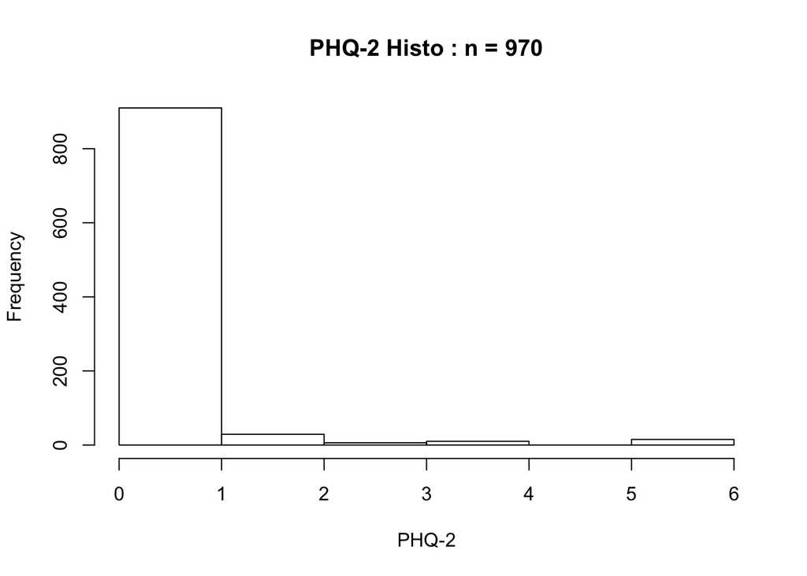

```r
####

#demographics and lab historgrams
#print histogram of phq-2/9s for people

hist(overlap_group$PHQ.2[which(!is.na(overlap_group$PHQ.2))], main = paste0("PHQ-2 Histo : n = ", length(which(!is.na(overlap_group$PHQ.2)))), xlab = "PHQ-2", breaks = 8)
```

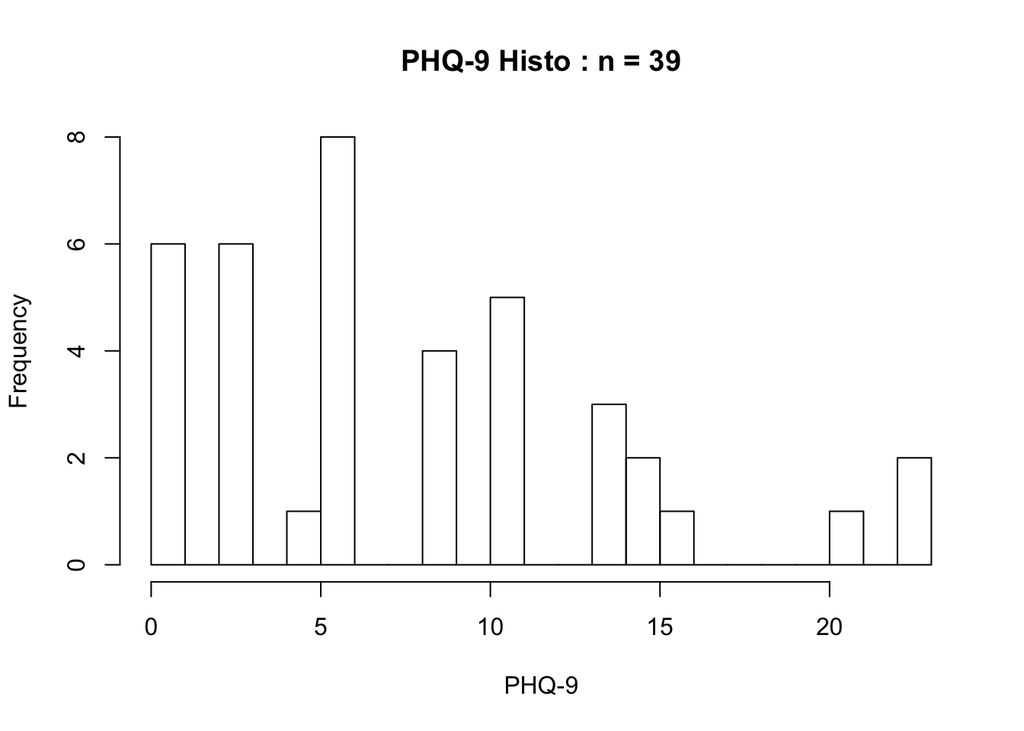

```r
hist(overlap_group$PHQ.9[which(!is.na(overlap_group$PHQ.9))], main = paste0("PHQ-9 Histo : n = ", length(which(!is.na(overlap_group$PHQ.9)))), xlab = "PHQ-9", breaks = 30)
```

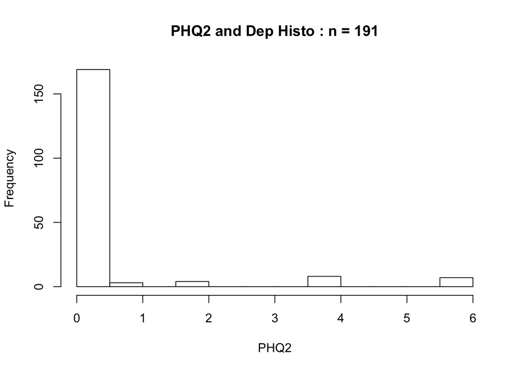

```r
#fcode histos
hist(dep_df$PHQ.2, main = paste0("PHQ2 and Dep Histo : n = ", num_phq2_and_dep), xlab = paste0("PHQ2"))
```

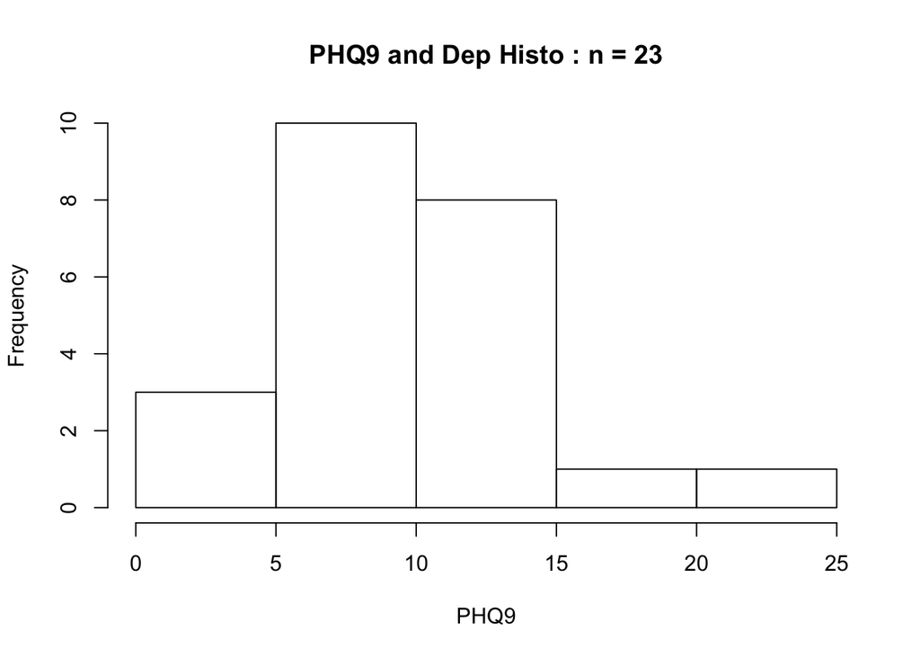

```r
hist(dep_df$PHQ.9,main = paste0("PHQ9 and Dep Histo : n = ", num_phq9_and_dep), xlab = paste0("PHQ9"))
```

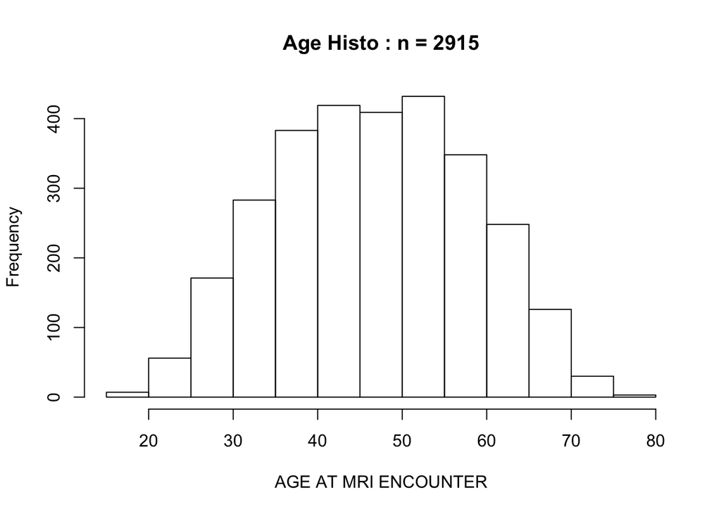

```r
###

#age histogram
hist(overlap_group$MRI_ENC_AGE[which(!is.na(overlap_group$MRI_ENC_AGE))], main = paste0("Age Histo : n = ", length(which(!is.na(overlap_group$MRI_ENC_AGE)))), xlab = "AGE AT MRI ENCOUNTER")
```

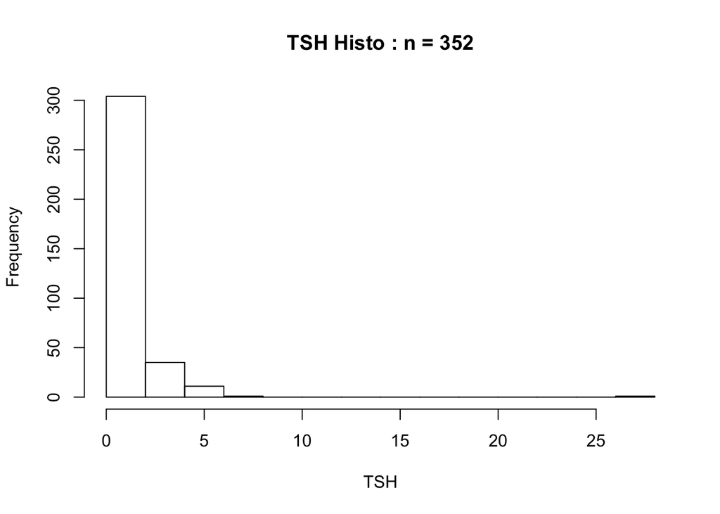

```r
#tsh
hist(overlap_group$TSH[which(!is.na(overlap_group$TSH))], main = paste0("TSH Histo : n = ", length(which(!is.na(overlap_group$TSH)))), xlab = "TSH")
```

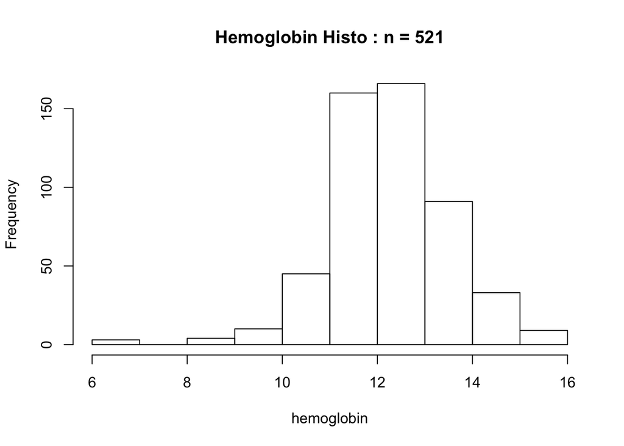

```r
#hemoglobin
hist(overlap_group$hemoglobin[which(!is.na(overlap_group$hemoglobin))], main = paste0("Hemoglobin Histo : n = ", length(which(!is.na(overlap_group$hemoglobin)))), xlab = "hemoglobin")
```

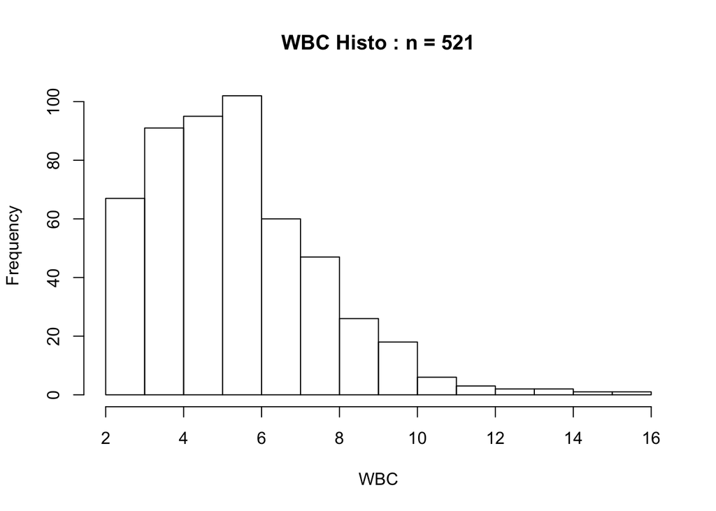

```r
#wbc
hist(overlap_group$WBC[which(!is.na(overlap_group$WBC))], main = paste0("WBC Histo : n = ", length(which(!is.na(overlap_group$WBC)))), xlab = "WBC")
```

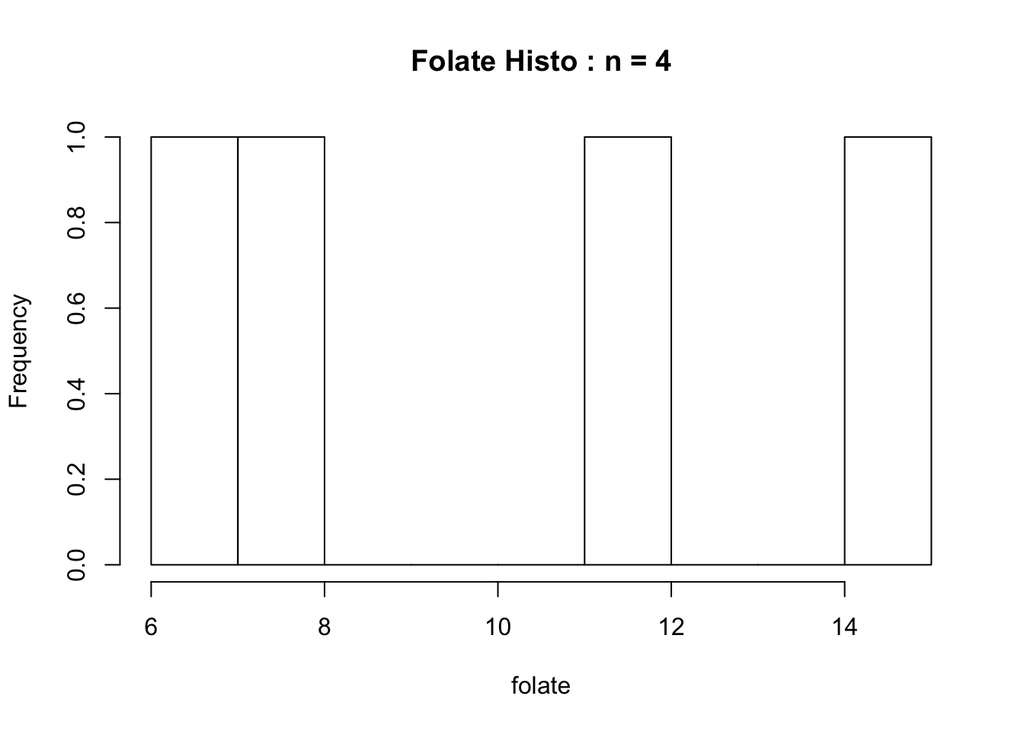

```r
#folate
hist(overlap_group$FOLATE[which(!is.na(overlap_group$FOLATE))], main = paste0("Folate Histo : n = ", length(which(!is.na(overlap_group$FOLATE)))), xlab = "folate", breaks = 10)
```